# Experimental Sociology - Week 02 - In Class

Analytical Methods: Decision & Game Theory

Published

2025-04-16

# Open Questions

Besides the pre-class assignment?

# Problem 2

Look at Table 1. Calculate the the expected utilities for each action if $p=0.25$.

Table 1: Payoff matrix for a fictitious social scenario.

| **actions \ states of the world** | **sunny weather** $(p)$ | **rainy weather** $(1-p)$ |
| --- | --- | --- |
| **summer clothes** | $u(x_{S,S})=10$ | $u(x_{S,R})=4$ |
| **winter clothes** | $u(x_{W,S})=2$ | $u(x_{S,S})=3$ |
| **rain clothes** | $u(x_{S,S})=5$ | $u(x_{S,S})=8$ |

## Solution

The **expected utility** $EU$ of choosing $a \in A$ is:

$$\mathrm{EU}(a) = \sum_{\omega \in \Omega} p(\omega) \cdot u\bigl(x_{a,\omega}\bigr)$$

Hence we have:

- $EU(a_S) = 0.25 \cdot 10 + (1-0.25) \cdot 4 = 5.5$,
- $EU(a_W) = 0.25 \cdot 2 + (1-0.25) \cdot 3 = 2.75$, and
- $EU(a_R) = 0.25 \cdot 5 + (1-0.25) \cdot 8 = 7.25$.

Hence if $p=0.25$ this person would choose $a_R$, i.e., rain clothes.

## Exploring the General Case

To better understand the model, we now consider a more general scenario where the probability of sunny weather, (p), can vary continuously between 0 and 1.

### Guiding Questions

1. **Which action is chosen for which value of** $p$?  
   That is, how do preferences over actions change as sunny weather becomes more or less likely?
2. **What general hypotheses can be derived from this model?**  
   Can we make predictions about decision patterns or critical thresholds based on the expected utility structure?

### Visualizing Expected Utilities

Since we already have the expected utility functions for each action, we can plot them as a function of $p$. This visualization allows us to see at which values of $p$ each action becomes optimal, and how the model supports hypothesis generation.

**Show R Code (expected utilities graph)**

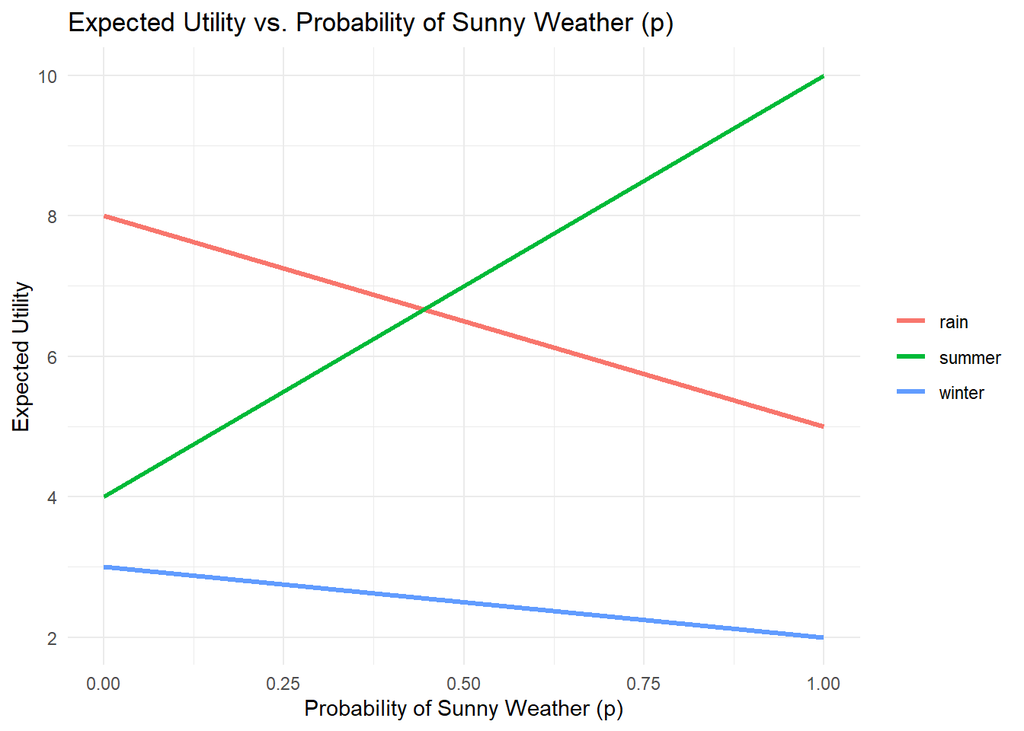

Figure 1. Expected utilities for different values of $p$

```r
# Load libraries
library(ggplot2)
library(dplyr)

# Create a sequence of p values from 0 to 1
p_values <- c(0,1)

# Build a data frame of expected utilities
df <- data.frame(
  p = p_values,
  summer = p_values * 10 + (1 - p_values) * 4,
  winter = p_values *  2 + (1 - p_values) * 3,
  rain   = p_values *  5 + (1 - p_values) * 8
)

# Reshape data into a "long" format for easier plotting
df_long <- df %>%
  tidyr::pivot_longer(
    cols = c("summer", "winter", "rain"),
    names_to = "action",
    values_to = "expected_utility"
  )

# Plot with ggplot
ggplot(df_long, aes(x = p, y = expected_utility, color = action)) +
  geom_line(size = 1.2) +
  labs(
    title = "Expected Utility vs. Probability of Sunny Weather (p)",
    x = "Probability of Sunny Weather (p)",
    y = "Expected Utility"
  ) +
  theme_minimal() +
  theme(legend.title = element_blank())
```

### Determining the critical value

In addition, we can determine the critical value $p^*$, for which an actor is indifferent between action $a_S$ and $a_R$:

$$EU(a_S) = EU(a_R)$$

$$p \cdot 10 + (1-p) \cdot 4 = p \cdot 5 + (1-p) \cdot 8$$

Rearrange the equation to p:

$$p^* = \frac{8 - 4}{10-4-5+8}=\frac{4}{9}$$

Or with R:

**Show R Code (critical p)**

```r
# This is a function to get the mixed Nash equilbirium strategy for the 2-player-2-strategies case
get_indiff <- function(u_aS_1, u_aS_2, u_aR_1, u_aR_2) {
  p <- (u_aR_2 - u_aS_2) / (u_aS_1 - u_aS_2 - u_aR_1 + u_aR_2)

  # if the package MASS is installed, then try to return a fraction instead of a real number
  if(!require("MASS")) return(p)
    else return(MASS::fractions(p))
}

p_indiff = get_indiff(u_aS_1 = 10,
                      u_aS_2 =  4,
                      u_aR_1 =  5,
                      u_aR_2 =  8)

print(paste0("p^* = ",p_indiff))
```

```
[1] "p^* = 4/9"
```

Hence we know the critical value $p^*$ is $\frac{4}{9}$.

### Adding Measurement (or Modelling) Errors

So far, we’ve assumed that utility values are known precisely and used uniformly by all individuals. However, in real-world decision-making, people may perceive or experience these utilities with some degree of error—due to individual differences, noise in perception, or uncertainty in the model itself.

To capture this, we simulate decision-making under **measurement error** by adding small random perturbations to each individual’s utilities. This allows us to explore how robust the model’s predictions are when choices are “blurred” by cognitive or contextual variability.

The plot below shows how the number of individuals choosing summer clothes changes with the probability of sunny weather, $p$, under different levels of random noise ($\eta$).

**Show R Code (Decision Theory Simulation, static)**

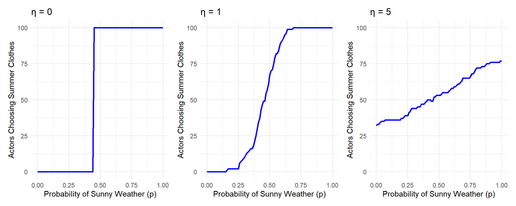

Figure 2. Simulation results with 100 actors, for different levels of noise (η = 0, 1, 5).

```r
library(ggplot2)
library(dplyr)
library(patchwork)  # for combining plots

simulate_choice_plot <- function(eta, n = 100) {
  # Errors for each individual and condition
  e_ss <- rnorm(n, mean = 0, sd = eta)
  e_sr <- rnorm(n, mean = 0, sd = eta)
  e_rs <- rnorm(n, mean = 0, sd = eta)
  e_rr <- rnorm(n, mean = 0, sd = eta)

  p_seq <- seq(0, 1, length.out = 101)
  results <- data.frame(p = p_seq, summer_count = NA)

  for (i in seq_along(p_seq)) {
    p <- p_seq[i]

    EU_summer <- p * (10 + e_ss) + (1 - p) * (4 + e_sr)
    EU_rain   <- p * (5 + e_rs)  + (1 - p) * (8 + e_rr)

    results$summer_count[i] <- sum(EU_summer > EU_rain)
  }

  ggplot(results, aes(x = p, y = summer_count)) +
    geom_line(color = "blue", size = 1) +
    labs(
      title = paste("η =", eta),
      x = "Probability of Sunny Weather (p)",
      y = "Actors Choosing Summer Clothes"
    ) +
    ylim(0, 100) +
    theme_minimal()
}

set.seed(42)

# Create the three plots
p0 <- simulate_choice_plot(0)
p1 <- simulate_choice_plot(1)
p5 <- simulate_choice_plot(5)

# Combine them into one row
p0 + p1 + p5
```

There is even a dynamic shiny version:

**Show R Code (Decision Theory Simulation, shiny)**

```r
library(shiny)
library(ggplot2)

# Define the User Interface
ui <- fluidPage(
  titlePanel("Summer vs. Rain Clothes Decision Simulation"),
  sidebarLayout(
    sidebarPanel(
      # Slider for noise (controls the "blurriness" of preferences)
      sliderInput("eta",
                  "Noise (η) as Standard Deviation:",
                  min = 0, max = 5, value = 0, step = 0.1),
    ),
    mainPanel(
      plotOutput("choicePlot")
    )
  )
)

# Define the Server logic
server <- function(input, output) {

  output$choicePlot <- renderPlot({
    n <- 100  # number of individuals
    eta <- input$eta

    # For each individual, generate four independent error terms:
    # e_ss: Error for summer clothes in sunny weather
    # e_sr: Error for summer clothes in rainy weather
    # e_rs: Error for rain clothes in sunny weather
    # e_rr: Error for rain clothes in rainy weather
    e_ss <- rnorm(n, mean = 0, sd = eta)
    e_sr <- rnorm(n, mean = 0, sd = eta)
    e_rs <- rnorm(n, mean = 0, sd = eta)
    e_rr <- rnorm(n, mean = 0, sd = eta)

    # Generate a sequence of p values (probability of sunny weather) from 0 to 1 with 101 steps
    p_seq <- seq(0, 1, length.out = 101)

    # Initialize a data frame to store the result for each p value
    results <- data.frame(p = p_seq, summer_count = NA)

    # For each p compute how many people choose summer clothes
    for (i in seq_along(p_seq)) {
      p <- p_seq[i]

      # Compute individual expected utilities:
      # Expected utility for summer clothes:
      EU_summer <- p * (10 + e_ss) + (1 - p) * (4 + e_sr)

      # Expected utility for rain clothes:
      EU_rain   <- p * (5 + e_rs)  + (1 - p) * (8 + e_rr)

      # Count how many individuals choose summer clothes (i.e., EU_summer > EU_rain)
      results$summer_count[i] <- sum(EU_summer > EU_rain)
    }

    # Plot: x-axis is the probability of sunny weather; y-axis is the count choosing summer clothes
    ggplot(results, aes(x = p, y = summer_count)) +
      geom_line(color = "blue", size = 1.2) +
      labs(
        title = "Number of People Choosing Summer Clothes vs. p",
        subtitle = "Simulation of 100 Individuals with Noisy Utilities",
        x = "Probability of Sunny Weather (p)",
        y = "Actors Choosing Summer Clothes"
      ) +
      theme_minimal()
  })
}

# Create the Shiny app
shinyApp(ui = ui, server = server)
```

### Conclusions

Depending on our confidence about the model and the measurement of the utilities given in Table 1, we can formulate different predictions:

- H1a: The higher the probability of sunny weather ($p$), the higher the chances that persons will wear summer clothes. (low confidence)
- H1b: If $p>\frac{4}{9}$, everybody will wear summer cloths, otherwise everybody will wear rain clothing. (high confidence)

Winter clothing is always inferior to rain or summer clothing (winter clothing is strictly dominated by the other two actions). Therefore we predict:

- H2: Winter clothing is never chosen in this scenario.

# Problem 3

Model a socially relevant decision situation, including important variables.

# Problem 4

Look at the game shown in Table 2. This game also has a third equilibrium in mixed strategies; determine it.

Table 2: A coordination game with two pure Nash equilibria.

|  | Player 2: Refrain | Player 2: Arm |
| --- | --- | --- |
| **Player 1: Refrain** | 3, 3 | 0, 2 |
| **Player 1: Arm** | 2, 0 | 1, 1 |

We know this game has two pure strategy Nash equilibria:  
- Both players **Refrain** $(a_{1R},a_{2R})$ or for simplicity $(R,R)$, and  
- Both players **Arm** $(a_{1A},a_{2A})$ or for simplicity $(A,A)$.

To find the **mixed strategy equilibrium**, we assume each player randomizes between the two strategies.

Let $p_2$ be the probability that **Player 2** chooses *Refrain*. Then Player 1 is indifferent between their two actions if:

$$EU_1(a_{1R}) = EU_1(a_{1A})$$

$$p_2 \cdot 3 + (1-p_2) \cdot 0 = p_2 \cdot 2 + (1-p_2) \cdot 1$$

Solving for $p_2$:

$$3p_2 = 2p_2 + 1 - p_2 \Rightarrow p_2 = \frac{1}{2}$$

Or using R with the same `get_indiff()` function from our decision theory section:

**Show R Code (critical p)**

```r
p_indiff = get_indiff(u_aS_1 = 3,
                      u_aS_2 = 0,
                      u_aR_1 = 2,
                      u_aR_2 = 1)

print(paste0("p_2^* = ",p_indiff))
```

```
[1] "p_2^* = 1/2"
```

**Note**

A **symmetric game** is a game where the players have **identical strategy sets**, and the same **payoffs depend only on the strategies chosen**, not on who is playing them.

In other words, if the players **swap roles**, the structure of the game and the outcomes remain the same.

The mixed strategy profile than is the Nash equilibrium is:

$$\sigma^* = \left( (0.5,a_{1R}; 0.5, a_{1A}), (0.5,a_{2R}; 0.5, a_{2A}) \right)$$

Or, simply, since there are only two actions per player, specifying one probability suffices:

$$\sigma^*=((0.5,0.5))$$

# Problem 5

Remember Boudon’s (1977) model of relative deprivation? It considers only three factors: the costs $c$ of applying for a promotion, the benefits $b$ of receiving the promotion, and the relative share of available positions $f$, all of which are assumed to be common knowledge.

## Subproblem 1

Model this situation with $n=2$ and $f=.5$.

Each actor has two strategies: **Refrain** or **Apply** for a promotion.

Applying leads to a cost $c$, but may yield a benefit $b$, where $b > c$. The payoff matrix is shown in Table 3.

Table 3: A promotion game with two players.

|  | Player 2: Refrain | Player 2: Apply |
| --- | --- | --- |
| **Player 1: Refrain** | $0, 0$ | $0, b-c$ |
| **Player 1: Apply** | $b - c, 0$ | $0.5 \cdot b - c, 0.5 \cdot b - c$ |

## Subproblem 3 - Nash Equilibria Analysis

Let’s determine the Nash equilibria of this game.

If both players **refrain**, they receive 0. But each has a **unilateral incentive to deviate** and apply, because applying yields $b - c > 0$. So $(a_{1R}, a_{2R})$ is **not** a Nash equilibrium.

If both players **apply**, then each has a 50% chance of receiving the promotion, and they both pay the cost $c$. The expected payoff is:

$$\mathrm{EU}_i(a_{iA}) = 0.5 \cdot b - c$$

Whether this outcome is stable depends on the relation between $b$ and $c$.

#### Case 1: $2c<b$

Here, the benefit is more than twice the cost. Then:

$$0.5 \cdot b - c > 0$$

This implies that each player prefers to apply rather than unilaterally refrain. Therefore, the strategy profile

$$(a_{1A}, a_{2A})$$

is the **only Nash equilibrium** is this game. Our prediction, then, is that **both players apply**.

#### Case 2: $2c>b$

Here, the benefit is less than twice the cost (though we still assume $b > c$). Then:

$$0.5 \cdot b - c < 0$$

This means the **expected utility of both applying is negative**. In other words, if a player expects the other to apply, they would prefer to **refrain** to avoid paying the cost for a low chance of success.

As a result, the **symmetric outcome** where both players apply — $(a_{1A}, a_{2A})$ — is **no longer a Nash equilibrium**, because both players have an incentive to deviate.

In this case, only the **asymmetric profiles** survive as **pure strategy Nash equilibria**:

- Player 1 applies, Player 2 refrains $(a_{1A}, a_{2R})$
- Player 2 applies, Player 1 refrains $(a_{1R}, a_{2A})$

These are stable: the applying player receives a payoff of $b - c > 0$, and the refraining player has no incentive to deviate, since switching to “Apply” would reduce their expected payoff.

Yet, there’s another **Nash equilibrium** in **mixed strategies** that emerges in this case.

**Note**

As a rule of thumb, most games have an odd number of Nash equilibria. If two pure strategy equilibria exist, it often implies the existence of a third — usually a **mixed strategy** equilibrium that “blends” the pure strategies.

To find this third Nash equilibrium, we set up the standard indifference condition. Player 1 must be indifferent between applying and refraining:

$$EU_1(a_{1R}) = EU_1(a_{1A})$$

That is (let $p_2$ the probability that player 2 applies):

$$p_2 \cdot 0 + (1 - p_2) \cdot 0 = p_2 \cdot (0.5 \cdot b - c) + (1 - p_2) \cdot (b - c)$$

This simplifies to:

$$0 = - 0.5 \cdot p_2 \cdot b + b - c$$

Solving this equation yields the **critical probability** $p_2^*$ at which Player 1 is indifferent between the two strategies — and similarly for Player 2, due to the game’s symmetry.

$$p_2 = \frac{2(b - c)}{b}$$

## Subproblem 2

Try to derive the general function of $p$ for any given number of players $n$ and promotion slots $k$.

Let
$$\begin{aligned}
n & \text{ - number of players} \\
k & \text{ - number of available (promotion) positions} \\
a & \text{ - number of applicants for the positions} \\
c & \text{ - cost of applying to a position} \\
b & \text{ - benefit of receiving a position} \\
\end{aligned}$$

The probability $s$ of successfully securing a position when applying is given by:

$$s = \Biggl\{
\begin{array}{ll}
\frac{k}{a} & \text{if } a > k \\
1 & \text{if } a \leq k
\end{array}$$

Accordingly, the expected utility for a player $i \in N$ who applies is:

$$EU_i(a_{iA}) = E(k,a) = \Biggl\{
\begin{array}{ll}
\frac{k}{a} \cdot b - c & \text{if } a > k \\
b-c & \text{if } a \leq k
\end{array}$$

Assuming, as before, that refraining yields utility $0$, we can summarize the payoffs for player $i$ depending on how many of the other $n-1$ players choose to apply:

Table 4: Utilities for a player $i$ in a promotion game with $n - 1$ other players, as a function of how many others apply. Note that $E(k,\cdot)$ is indexed one higher than the number of other applicants, since player $i$ joins them when applying.

|  | $0$ | $1$ | $2$ | … | $h$ | … | $n-1$ |
| --- | --- | --- | --- | --- | --- | --- | --- |
| **Player** $i$: Refrain | $0$ | $0$ | $0$ | … | $0$ | … | $0$ |
| **Player** $i$: Apply | $E(k,1)$ | $E(k,2)$ | $E(k,3)$ | … | $E(k,h+1)$ | … | $E(k,n)$ |

So what will rational players do?

To answer this, we draw on insights from the simpler two-player case. We’ll first identify conditions under which always applying is rational. Then, we’ll explore more nuanced scenarios, where players may mix strategies depending on the expected number of other applicants.

### Case 1: Everyone Applying

To analyze this scenario, assume the most extreme case—everyone applies. Additionally, we exclude the trivial case where $k = n$ (i.e., there are enough positions for everyone), since in that case, applying guarantees a position and there’s no strategic tension.

Under the assumption that all $n$ players apply, the expected utility for any player $i$ is:

$$EU_i(a_{iA},a_{-iA}) = \frac{k}{n}\cdot b -c$$

For this to be a **Nash equilibrium**, applying must yield a higher payoff than not applying—that is, it must be strictly better than 0:

$$\frac{k}{n}\cdot b -c > 0$$

This is our condition for Case 1. If the inequality holds, **applying** is a **dominant strategy** for every player, and the strategy profile where all players apply is the only Nash equilibrium.

### Case 2: The other case

In this case, we consider situations where **not everyone applies**. As before, we assume that there may be multiple pure-strategy Nash equilibria in which **some players apply and others refrain**.

#### Asymmetrical Pure Nash Equilibria

Let’s start with the extreme: **no one applies**. In this scenario, a player has a **unilateral incentive to deviate** and apply as long as the expected utility from also applying is positive—that is, as long as $E(k,a_c+1) > 0$, with $a_c$ the current number of applicants.

This logic continues: more players will apply as long as the utility from applying remains positive. The process stops when the expected utility becomes zero or negative:

$$E(k,a) \leq 0$$

Since we know that applying is **always beneficial when** $a \leq k$, we can restrict our attention to the case where $a > k$. The condition for applying to still be worthwhile is:

$$\frac{k}{a}\cdot b - c > 0$$
Solved for $a$, we get:

$$a < \frac{k \cdot b}{c}$$

Let’s denote the **maximum number of applicants** who would still prefer to apply as $a^*$. Using floor notation to ensure an integer value:

$$a^* = \lfloor \frac{k \cdot b}{c} \rfloor$$
This tells us that **exactly** $a^*$ players would apply in equilibrium, while the remaining$n - a^*$ would refrain.

There are $\binom{n}{a^*}$ asymmetrical pure Nash equilibria corresponding to the different combinations of exactly $a^*$ players choosing to apply. For example, in a game with $n = 3$ players and $a^* = 2$, there are three such equilibria (for simplicity the equilibrium is given as $(p_{1A},p_{2A},p_{3A})$):

$$(1,1,0), (1,0,1), (0,1,1)$$

or more formally (but less readable):

$$\begin{split}
\big( ((1,a_{1A};0,a_{1R}),(1,a_{2A};0,a_{2R}),(0,a_{3A};1,a_{3R})), \\
(1,a_{1A};0,a_{1R}),(0,a_{2A};1,a_{2R}),(1,a_{3A};0,a_{3R})), \\
((0,a_{1A};1,a_{1R}),(1,a_{2A};0,a_{2R}),(1,a_{3A};0,a_{3R})) \big)
\end{split}$$

#### Symmetrical Mixed Nash Equilibria

Consider the case where every player applies with the same positive probability $p^*$; that is, we have a symmetric mixed Nash equilibrium. In equilibrium, no player benefits from unilaterally changing their strategy. This condition implies that a player’s expected payoff from applying equals her expected payoff from not applying:

$$EU_i(a_{iA})=EU_i(a_{iR})$$

While the right-hand side of this equation is simply $0$. Because each of the other $n-1$ players applies independently with probability $p$, the number of other applicants follows a binomial distribution. Thus, the expected payoff for applying can be written as

$$\sum^{n-1}_{a=0}{\binom{n-1}{a}p^a(1-p)^{n-1-a} \cdot E(k,a+1)}=0$$
Split:

where $E(k,a+1)$ is the payoff obtained when a total of $a+1$ players apply (including the focal player), and $k$ is the threshold such that if the number of applicants is at most $k$, an applicant receives the full benefit $b$ (net of cost $c$); otherwise, the benefit is shared proportionally.

1. Splitting the sum into two parts clarifies the payoff structure:

   When $a \leq k-1$:

   The total number of applicants is at most $k$ (i.e. $a+1 \le k$), so that each applicant receives the full net benefit. The contribution to the expected payoff is

$$\sum^{k-1}_{a=0}{\binom{n-1}{a}p^a(1-p)^{n-1-a} \cdot (b-c)}$$

2. When $a \geq k$:

In this case the total number of applicants exceeds $k$ (i.e. $a+1 \geq k+1$), and the benefit is shared among the applicants. Each applicant obtains $\displaystyle \frac{k}{a+1}b-c$. The corresponding contribution is

$$\sum^{n-1}_{a=k}{\binom{n-1}{a}p^a(1-p)^{n-1-a} \cdot (\frac{k}{a+1}\cdot b -c)}$$
Thus, the equilibrium condition becomes

$$\sum^{k-1}_{a=0}{\binom{n-1}{a}p^a(1-p)^{n-1-a} \cdot (b-c)}+ \sum^{n-1}_{a=k}{\binom{n-1}{a}p^a(1-p)^{n-1-a} \cdot (\frac{k}{a+1}\cdot b -c)}=0$$

Unfortunately, this equation cannot be algebraically rearranged into a simple closed-form expression for $p$. However, it can be solved numerically.

Below is an R script that numerically solves for the equilibrium probability $p$ using the uniroot function:

```r
# Define the function f(p) corresponding to the equation:
eu <- function(p, n, k, b, c) {
  a <- 0:(n-1)

  # Compute the terms of the sum:
  # For a <= k, use: binom(n-1, a-1)*p^(a-1)*(1-p)^(n-a)*(b-c)
  # For a > k, use: binom(n-1, a-1)*p^(a-1)*(1-p)^(n-a)*((k/a)*b - c)
  terms <- ifelse(a < k,
                  choose(n - 1, a) * p^a * (1 - p)^(n - 1 - a) * (b - c),
                  choose(n - 1, a) * p^a * (1 - p)^(n - 1 - a) * ((k / (a+1)) * b - c)
  )

  # Return the sum of the terms
  sum(terms)
}

# Example parameter values
n <- 2    # total number of trials (or n-1 in some interpretations)
k <- 1    # given k, with k <= n
b <- 3.0  # parameter b
c <- 2.0  # parameter c

# Use uniroot to solve for p in the interval (0,1).
# We avoid p exactly equal to 0 or 1 by using small offsets.

if ( (k/n) * b -c >= 0 ) {
  result <- 1
} else {
  result <- uniroot(eu, lower = 1e-6, upper = 1 - 1e-6, n = n, k = k, b = b, c = c)$root
}

# Display the solution
cat("The solution is p =", result, "\n")
```

In this script, the function
$$eu(p,n,k,b,c)$$
computes the excess expected utility from applying (which must equal zero in equilibrium). Since an analytical solution for $p$ is not available, we use uniroot to determine $p^*$ numerically. This method yields the application probability for a symmetric mixed Nash equilibrium given the parameters $n$, $k$, $b$, and $c$.

### Approximation

For sufficiently large $n$, we can approximate the equilibrium condition by using a simplified argument. Recall that in equilibrium we require

$$EU_i(a_{iA})=EU_i(a_{iR})$$

Suppose that when a player applies her probability of success is $p_s$. If success yields a net benefit $(b-c)$ and failure yields a payoff of $-c$, then her expected payoff from applying is

$$\begin{align*}
p_s \cdot (b-c) + (1-p_s) \cdot (0 - c) = 0 \\
p_s \cdot b - c = 0
\end{align*}$$

On the other hand, consider the following approximation. If there are $k$ free positions among $n$ players and each player applies with probability $p$, then the expected number of applicants is $n \cdot p$. Assuming that applicants share the $k$ positions equally, a given applicant’s chance of success can be approximated by the ratio of free positions to the expected number of applicants:

$$p_s \approx \frac{k}{n} \cdot \frac{n}{a} = \frac{k}{a} = \frac{k}{n \cdot p}$$

Equate the two expressions for $p_s$:

$$\frac{k}{n\cdot p} \cdot b - c = 0$$

Solving for $p$, we obtain

$$p^* =\frac{k}{n}\cdot \frac{b}{c}=f\cdot \frac{b}{c}$$

with $f = \frac{k}{n}$ as the relative share of free positions.

This linear approximation for $p^*$ relies on replacing the random number of applicants with its expectation, and it ignores the variability inherent in the binomial structure. Hence, while the approximation becomes increasingly accurate for large $n$, for small $n$ there may be significant differences from the exact solution.

#### Asymmetrical Mixed Nash Equilibria

If you thought we were done, you were wrong! There’s actually a plethora of other equilibria. For example, one player might always apply while the others play a mixed Nash strategy. (Don’t believe me? Try a game with $n=3$, $k=2$, $b=5$, $c=4$, and $\sigma^*=(1,3/5,3/5)$). Still, these equilibria aren’t particularly compelling—unless you have strong reasons to believe that players will coordinate or gravitate toward that specific outcome. In fact, they’re often considered so unlikely that many academic papers completely ignore them (Berger and Diekmann 2015)!

# Extra Tasks

Remember this example from Table 5? While it’s tempting to think of ticket inspections as a kind of natural force—random and unpredictable—that view overlooks a key detail: someone actually has to choose to inspect. So why not bring them into the picture and turn this into a proper game?

Table 5: Payoff matrix for the ticket decision.

| **actions \ states of the world** | **Ticket inspection (**$p$) | **No ticket inspection** ($1-p$) |
| --- | --- | --- |
| **Buy ticket** ($a_T$) | $-T$ | $-T$ |
| **Don’t buy ticket** ($a_{NT}$) | $-F$ | $Q$ |

## Modelling

To transform this decision problem into a game, we need to introduce a second player—the inspector.

**Step 1: Define their actions**. This is straightforward: the inspector can either inspect ($a_{2I}$) or not inspect ($a_{2NI}$) tickets.

**Step 2: Assign payoffs**. For Player 1, the payoffs stay the same (with $Q$ normalized to 0, as before). For Player 2, we assume:

- No inspection yields a payoff of 0.
- Inspection costs $C$, but if Player 1 is caught without a ticket, the inspector receives a bonus $B$ (with $B>C>0$)

This leads us to the following payoff matrix:

Table 6: Payoff matrix for the ticket inspection game (Player 1 and Player 2).

| **actions \ states of the world** | **Ticket inspection** $(a_{2I})$ | **No ticket inspection** $(a_{2NI})$ |
| --- | --- | --- |
| **Buy ticket** ($a_{1T}$) | $-T, -C$ | $-T, 0$ |
| **Don’t buy ticket** ($a_{1NT}$) | $-F, B-C$ | $0, 0$ |

## Analyzing

Now that we have everything in place, we can analyze this game.

Let’s denote the players’ strategies as:

- Player 1 buys a ticket with probability $p_1$, and doesn’t buy with probability $1 - p_1$.
- Player 2 inspects with probability $p_2$, and doesn’t inspect with probability $1 - p_2$.

### Pure Nash Equilibria

Let us first check whether this game has any pure Nash equilibria.

Hence, **no pure strategy profile forms a Nash equilibrium**. And because it is a finite game (= finite number of players with a finite number of actions), we now that at least one Nash equilibrium must exist.

### Mixed Nash Equilibrium

To find the **mixed-strategy Nash equilibrium**, we look for values of $p_1^*$ and $p_2^*$ such that both players are indifferent between their actions. Since this game is not a symmetric game we have to calculate it for both seperatly.

#### Player 1 strategy

By this time you should know that in order to calculate $p_1$ we need the $EU$ of Player 2:

$$\begin{align*}
EU_2(a_{2I})=EU_2(a_{2NI}) \\
p_1 \cdot (- C) + (1 - p_1) \cdot (B-C) = 0
\end{align*}$$

Solving for $p_1$ we get:

$$p_1^* = \frac{B-C}{B}$$

#### Player 2 strategy

Similarly, we equate Player 1’s expected utilities to solve for $p_2$:

$$\begin{align*}
EU_1(a_{1T})=EU_1(a_{1NT}) \\
-T = p_2 \cdot (-F) + (1-p_2) \cdot 0
\end{align*}$$

Solving for $p_2$ we get:

$$p_2^* = \frac{T}{F}$$

## Conclusions

Now with this we can derive a number of hypotheses:

- The higher the ticket price $T$, the more likely to be inspected
- The higher the fine $F$, the less likely to be inspected
- The higher the bonus $B$, the more likely a ticket is bought
- The higher the inspection cost $C$, the less likely a ticket is bought
- $T$ and $F$ have no influence on the probability of a ticket being purchased[^1]
- $C$ and $B$ have no influence on the probability of an inspection

**Wait what???**

In this analysis, we conclude that it’s not the ticket price alone that determines how many people buy tickets, but rather the probability of inspection. At first glance, this may seem counterintuitive. However, this impression arises because the Nash equilibrium reflects the final outcome—not the dynamic path that leads there.

In reality, if the ticket price increases and the inspection probability $p_2$ remains unchanged, people become less inclined to buy a ticket, and so $p_1$ (the probability of buying) decreases. In response, Player 2 (the inspector) now has a stronger incentive to inspect, causing $p_2$ to increase. As inspections become more frequent, the cost of fare evasion rises, and passengers are once again more likely to buy tickets. This feedback loop continues until the system settles back at the equilibrium point—where each player’s strategy is a best response to the other’s.

### Graphical Representation

Below, you can see the **best response functions** for both players. These graphical representations might help us to determine equilibria in a game.

**Note**

A best response function, denoted $BR_i(a_{-i})$, shows the optimal strategy for player $i$ given the strategies chosen by the other player(s), represented by $a_{-i}$. In other words, it tells us how player $i$ should opimally behave in response to the actions of the others. If we know the best response functions for all players, a **Nash equilibrium** occurs at the point where these functions intersect—meaning that each player’s strategy is a best response to the others.

**Show R Code (Decision Theory Simulation, shiny)**

```r
# app.R
library(shiny)
library(ggplot2)

ui <- fluidPage(
  titlePanel("Best Response Functions in Ticket Inspection Game"),

  sidebarLayout(
    sidebarPanel(
      numericInput("T", "Ticket price (T):", value = 2, min = 0),
      numericInput("F", "Fine for no ticket (F):", value = 40, min = 0),
      numericInput("B", "Bonus for catching evader (B):", value = 20, min = 0),
      numericInput("C", "Cost of inspection (C):", value = 4, min = 0)
    ),

    mainPanel(
      plotOutput("brPlot"),
      verbatimTextOutput("equilibrium")
    )
  )
)

server <- function(input, output) {

  output$brPlot <- renderPlot({

    # define the utility function for player 1
    EU_1 <- function(T,F,p_2) {
      term1 = -T
      term2 = p_2 * (-F)
      term1 - term2
    }

    # define the utility function for player 1
    EU_2 <- function(B,C,p_1) {
      term1 = p_1 * (-C) + (1-p_1) * (B-C)
      term2 = 0
      term1 - term2
    }

    # calculate the critical values
    p_1_star <- (input$B - input$C) / input$B
    p_2_star <- input$T / input$F

    # Determines what is the best reponse for player 1 or 2 if the other chooses their p equal 0 or 1.
    BR1_0 = ifelse(EU_1(input$T, input$F, 0)>0, 0, 1)
    BR1_1 = ifelse(EU_1(input$T, input$F, 1)>0, 0, 1)
    BR2_0 = ifelse(EU_2(input$B, input$C, 0)>0, 0, 1)
    BR2_1 = ifelse(EU_2(input$B, input$C, 1)>0, 0, 1)

    # Create data for plotting
    x_vals = c(0,0, p_1_star, p_1_star, 1, 1)

    df <- data.frame(
      x = x_vals,
      BR1 = c(BR2_0, p_2_star, p_2_star, p_2_star, p_2_star, BR2_1),
      BR2 = c(BR1_0,    BR1_0,    BR1_0,    BR1_1, BR1_1, BR1_1)
    )

    ggplot(df, aes(x = x)) +
      geom_line(aes(y = BR1), color = "blue", size = 1.2, linetype = "solid") +
      geom_line(aes(y = BR2), color = "red", size = 1.2, linetype = "solid") +
      labs(
        title = "Best Response Functions",
        x = "p_1",
        y = "p_2",
        caption = "Blue: Player 1 | Red: Player 2"
      ) +
      theme_minimal() +
      ylim(0, 1)
  })

  output$equilibrium <- renderText({
    if (input$B == 0 || input$F == 0) {
      "Error: B and F must be greater than 0 to compute equilibrium."
    } else {
      p1_star <- round((input$B - input$C) / input$B, 3)
      p2_star <- round(input$T / input$F, 3)
      paste0("Equilibrium Strategies:\n",
             "Player 1 (buy ticket): p1* = ", p1_star, "\n",
             "Player 2 (inspect):     p2* = ", p2_star)
    }
  })
}

shinyApp(ui = ui, server = server)
```

## References

Berger, Joël, and Andreas Diekmann. 2015. “The Logic of Relative Frustration: Boudon’s Competition Model and Experimental Evidence.” *European Sociological Review* 31 (6): 725–37. https://doi.org/10.1093/esr/jcv071.

Boudon, Raymond. 1977. *The Unintended Consequences of Social Action*. London: Macmillan.

## Footnotes

[^1]: As long as $F>T>0$ and $B>C>0$ holds.

## Copyright

Copyright Sascha Grehl, 2025. All Rights Reserved